# data607_project4

karmaGyatso

2022-11-19

```r
library(tm)
library(knitr)
library(dplyr)
```

```r
library(wordcloud)
library(naivebayes)
library(e1071)
library(pROC)
```

## Introduction

It can be useful to be able to classify new “test” documents using already classified “training” documents. A common example is using a corpus of labeled spam and ham (non-spam) e-mails to predict whether or not a new document is spam.

For this project, you can start with a spam/ham dataset, then predict the class of new documents (either withheld from the training dataset or from another source such as your own spam folder). One example corpus: (https://spamassassin.apache.org/old/publiccorpus/ )[https://spamassassin.apache.org/old/publiccorpus/]

## loading files

The number of files are too many to upload in the GitHub. So, I have downloaded the files in the desktop and assigned a path in the variable to load in R.

```r
pathName_spam <- "/Users/karmagyatso/Documents/cunySps/data607/project4/spam_2"
file_names_spam <- list.files(pathName_spam)

head(file_names_spam)
```

```
## [1] "00001.317e78fa8ee2f54cd4890fdc09ba8176"
## [2] "00002.9438920e9a55591b18e60d1ed37d992b"
## [3] "00003.590eff932f8704d8b0fcbe69d023b54d"
## [4] "00004.bdcc075fa4beb5157b5dd6cd41d8887b"
## [5] "00005.ed0aba4d386c5e62bc737cf3f0ed9589"
## [6] "00006.3ca1f399ccda5d897fecb8c57669a283"
```

```r
length_spam <- length(file_names_spam)
length_spam
```

```
## [1] 1397
```

```r
pathName_ham <- "/Users/karmagyatso/Documents/cunySps/data607/project4/easy_ham_2"
file_names_ham <- list.files(pathName_ham)

head(file_names_ham)
```

```
## [1] "00001.1a31cc283af0060967a233d26548a6ce"
## [2] "00002.5a587ae61666c5aa097c8e866aedcc59"
## [3] "00003.19be8acd739ad589cd00d8425bac7115"
## [4] "00004.b2ed6c3c62bbdfab7683d60e214d1445"
## [5] "00005.07b9d4aa9e6c596440295a5170111392"
## [6] "00006.654c4ec7c059531accf388a807064363"
```

```r
length_ham <- length(file_names_ham)
length_ham
```

```
## [1] 1401
```

```r
file_names_spam <- file_names_spam[which(file_names_spam!="cmds")]
file_names_ham <- file_names_ham[which(file_names_ham!="cmds")]
```

##corpus creation - processing text data

```r
easy_ham_corpus <- pathName_ham %>%
  paste(., list.files(.), sep = "/") %>%
  lapply(readLines) %>%
  VectorSource() %>%
  VCorpus()

easy_ham_corpus
```

```
## <<VCorpus>>
## Metadata:  corpus specific: 0, document level (indexed): 0
## Content:  documents: 1401
```

```r
spam_corpus <- pathName_spam %>%
  paste(., list.files(.), sep = "/") %>%
  lapply(readLines) %>%
  VectorSource() %>%
  VCorpus()

spam_corpus
```

```
## <<VCorpus>>
## Metadata:  corpus specific: 0, document level (indexed): 0
## Content:  documents: 1397
```

## Cleaning data with Corplus

data contains garbage like numbers, puctuation, whitespace. So, first we will remove all the unnecessary data.

```r
Sys.setlocale("LC_ALL", "C")
```

```
## [1] "C/C/C/C/C/en_US.UTF-8"
```

```r
# easy ham emails
easy_ham_corpus <- easy_ham_corpus %>%
  tm_map(removeNumbers) %>%
  tm_map(removePunctuation) %>%
  tm_map(removeWords, stopwords()) %>%
  tm_map(stripWhitespace) %>%
  tm_map(stemDocument)
```

```r
#spam emails
spam_corpus <- spam_corpus %>%
  tm_map(removeNumbers) %>%
  tm_map(removePunctuation) %>%
  tm_map(removeWords, stopwords()) %>%
  tm_map(stripWhitespace) %>%
  tm_map(stemDocument)

spam_corpus
```

```
## <<VCorpus>>
## Metadata:  corpus specific: 0, document level (indexed): 0
## Content:  documents: 1397
```

We have 1401 documents on easy_ham and 1397 documents on spam. Combining these two corpuses.

```r
ham_or_spam_corpus <- c(easy_ham_corpus, spam_corpus)
```

```r
ham_or_spam_corpus
```

```
## <<VCorpus>>
## Metadata:  corpus specific: 0, document level (indexed): 0
## Content:  documents: 2798
```

##Building a Term Document Matrix

```r
tdm <- DocumentTermMatrix(ham_or_spam_corpus)
tdm
```

```
## <<DocumentTermMatrix (documents: 2798, terms: 84774)>>
## Non-/sparse entries: 528459/236669193
## Sparsity           : 100%
## Maximal term length: 949
## Weighting          : term frequency (tf)
```

##Creating word cloud

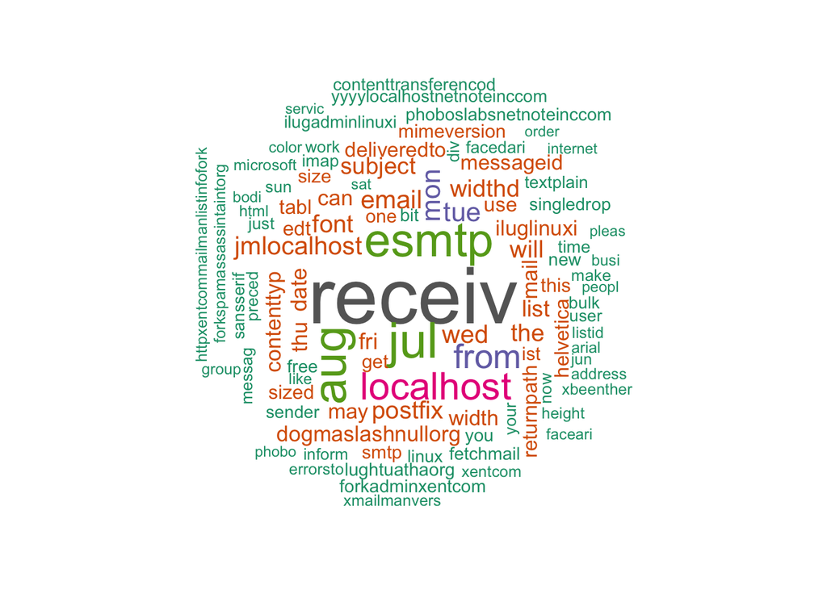

```r
wordcloud(ham_or_spam_corpus, max.words = 100, random.order = FALSE, rot.per=0.15, min.freq=5, colors = brewer.pal(8, "Dark2"))
```

## Creating Data Frames

Here we are creating a new data frame and unlist all the easy_ham in df_ham and df_spam and combine the data in to one data frame. We can use Naive Bayes classifier to find any key word present in a defined class to predict if the email is spam or ham.

```r
df_ham <- as.data.frame(unlist(easy_ham_corpus), stringsAsFactors = FALSE)
df_ham$type <- "ham"
colnames(df_ham)=c("text", "email")

df_spam <- as.data.frame(unlist(spam_corpus), stringsAsFactors = FALSE)
df_spam$type <- "spam"
colnames(df_spam)=c("text", "email")

df_ham_or_spam <- rbind(df_ham, df_spam)

kable(head(df_ham_or_spam))
```

| text | email |
| --- | --- |
| ReturnPath exmhworkersadminspamassassintaintorg | ham |
| DeliveredTo yyyylocalhostnetnoteinccom | ham |
| Receiv localhost localhost | ham |
| phoboslabsnetnoteinccom Postfix ESMTP id C | ham |
| jmlocalhost Wed Aug EDT | ham |
| Receiv phobo | ham |

Splitting the data by 80% as training data and 20% as test data.

```r
sample_size <- floor(0.80 * nrow(df_ham_or_spam)) # selecting sample size of 80% of the data for training.

set.seed(123)
train <- sample(seq_len(nrow(df_ham_or_spam)), size = sample_size)

train_ham_or_spam <- df_ham_or_spam[train, ]
test_ham_or_spam <- df_ham_or_spam[-train, ]

kable(head(train_ham_or_spam))
```

|  | text | email |
| --- | --- | --- |
| 188942 | 252 | spam |
| 134058 | ListId SpamAssassin Develop spamassassindevelexamplesourceforgenet | ham |
| 124022 |  | ham |
| 160997 | Attention Internet Domain Registr | spam |
| 226318 | zelignetnitconet jimnetnogginscom fdjnetnited zosonetnitconet | spam |
| 124507 |  | ham |

```r
kable(head(test_ham_or_spam))
```

|  | text | email |
| --- | --- | --- |
| 2 | DeliveredTo yyyylocalhostnetnoteinccom | ham |
| 28 | Wed Aug | ham |
| 30 | ratreepsuacth ESMTP id gLCUIl | ham |
| 40 | Refer TMDAdeepeddyvirciocom | ham |
| 42 | ContentTyp textplain charsetusascii | ham |
| 44 | XLoop exmhworkersspamassassintaintorg | ham |

## Corplus

Corpus is an R text processing package with full support for international text (Unicode). It includes functions for reading data from newline-delimited JSON files, for normalizing and tokenizing text, for searching for term occurrences, and for computing term occurrence frequencies (including n-grams).

Create and Clean Corpus and Create Term Document Matrix for Training and Test Data.

```r
# corpus creation
train_corpus <- Corpus (VectorSource(train_ham_or_spam$text)) # corpus training data
test_corpus <- Corpus(VectorSource(test_ham_or_spam$text)) # corpus test data

# corpus cleaning
train_corpus <- train_corpus %>%
  tm_map(removeNumbers) %>%
  tm_map(removePunctuation) %>%
  tm_map(removeWords, stopwords()) %>%
  tm_map(stripWhitespace)
test_corpus <- test_corpus %>%
  tm_map(removeNumbers) %>%
  tm_map(removePunctuation) %>%
  tm_map(removeWords, stopwords()) %>%
  tm_map(stripWhitespace)
train_tdm <- DocumentTermMatrix(train_corpus)
test_tdm <- DocumentTermMatrix(test_corpus)

train_tdm
```

```
## <<DocumentTermMatrix (documents: 289992, terms: 74021)>>
## Non-/sparse entries: 705756/21464792076
## Sparsity           : 100%
## Maximal term length: 868
## Weighting          : term frequency (tf)
```

```r
test_tdm
```

```
## <<DocumentTermMatrix (documents: 72499, terms: 29891)>>
## Non-/sparse entries: 175382/2166892227
## Sparsity           : 100%
## Maximal term length: 358
## Weighting          : term frequency (tf)
```

```r
train_corpus
```

```
## <<SimpleCorpus>>
## Metadata:  corpus specific: 1, document level (indexed): 0
## Content:  documents: 289992
```

```r
test_corpus
```

```
## <<SimpleCorpus>>
## Metadata:  corpus specific: 1, document level (indexed): 0
## Content:  documents: 72499
```

We need to filter data for training of data.

```r
spam <- subset(train_ham_or_spam, email == "spam")
ham <- subset(train_ham_or_spam, email == "ham")
```

limitting the observation upto 60 times for now.

```r
sixty_times_words<- findFreqTerms(train_tdm, 60)
length(sixty_times_words)
```

```
## [1] 1589
```

## create a classifier for each email

```r
train_tdm_2<- DocumentTermMatrix(train_corpus, control=list(dictionary = sixty_times_words))

test_tdm_2<- DocumentTermMatrix(test_corpus, control=list(dictionary = sixty_times_words))
```

```r
train_tdm_3 <- as.matrix(train_tdm_2)
train_tdm_3 <- as.data.frame(train_tdm_3)
class(train_tdm_3)
```

```
## [1] "data.frame"
```

```r
test_tdm_3 <- as.matrix(test_tdm_2)
test_tdm_3 <- as.data.frame(test_tdm_3)
class(test_tdm_3)
```

```
## [1] "data.frame"
```

Training the Naive Bayes classifier-

```r
classifier <- naiveBayes(train_tdm_3, factor(train_ham_or_spam$email))
```

##testing the model

```r
test_pred <- predict(classifier, newdata=test_tdm_3)
```

```r
table(predicted=test_pred,actual=test_tdm_3[,1])
```

```
##          actual
## predicted     0     1
##      ham  64614   553
##      spam  7332     0
```

```r
prednum<-ifelse(test_pred=="spam",1,2)

auc<-roc(as.factor(test_tdm_3[,1]),prednum)
```

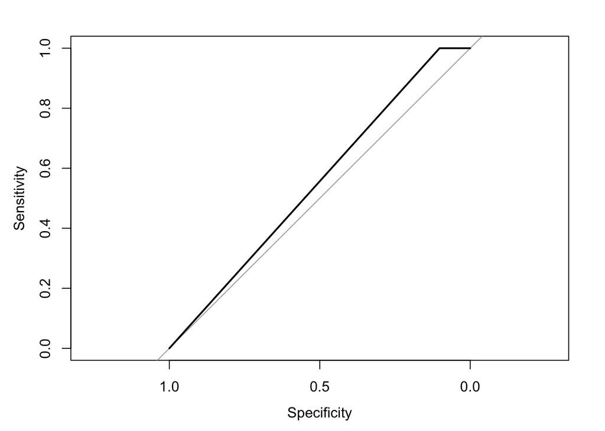

```r
plot(auc)
```

```r
auc$auc
```

```
## Area under the curve: 0.551
```

In the Confusion matrix , the diagonals are the correctly classified examples while the off-diagonals the incorrectly classifiec examples.

##Conclusion

This was a simple article on classifying text messages as ham or spam using some basic natural language processing and then building a naive Bayes text classifier.I urge the readers to implement and use the knowledge acquired from this article in making their own text classifiers and solving different problems related to text processing and NLP etc. Ofcourse,there are various other packages to do text processing and building such models.